### Question 3

Answer 3.a:

Given code for Matrix A:

```r
rm(list=ls())
A <- matrix(rpois(64,5), 8, 8)
A
```

```
##      [,1] [,2] [,3] [,4] [,5] [,6] [,7] [,8]
## [1,]    3    6    8    9    4    4   10    6
## [2,]    2    5    2    1    5    7    5    9
## [3,]    5    4    5   11    1    3    6    3
## [4,]    5    5    4    4    2    5    5    5
## [5,]    6    7    3    6    3    9    2    2
## [6,]    4    5    3    2    2    5    7    8
## [7,]    5    4    4    5    9    7    2    0
## [8,]    4    2    8    4    3    2    3    2
```

After looking for rpois() help using ?rpois we see the following

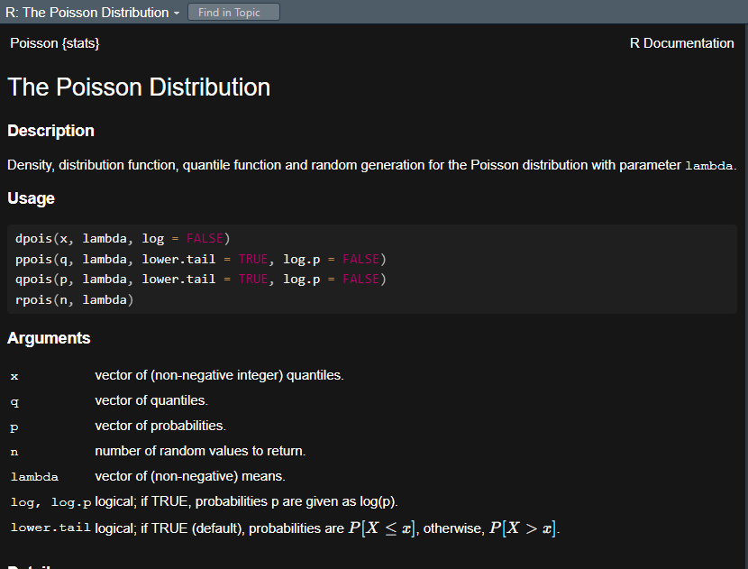

?rpois

Here are things happening in the give code:

1. rm(list=ls()): This line clears the workspace, removing any existing variables.
2. A <- matrix(rpois(64, 5), 8, 8): This line generates a matrix A with dimensions 8 x 8.
3. It uses the rpois() function, which generates random values from the Poisson distribution. The function takes two arguments: the number of values to generate (in this case, 64) and the mean parameter (in this case, 5). So, each element of matrix A is obtained by generating a random Poisson-distributed value with a mean of 5.

### Question 3

Answer 3.b:

Here is the given code for matric C:

```r
C= A %*% t(A)
C
```

```
##      [,1] [,2] [,3] [,4] [,5] [,6] [,7] [,8]
## [1,]  358  213  272  221  218  230  200  186
## [2,]  213  214  134  162  165  193  147  100
## [3,]  272  134  242  171  187  160  158  145
## [4,]  221  162  171  161  172  169  144  119
## [5,]  218  165  187  172  228  161  194  123
## [6,]  230  193  160  169  161  196  129  111
## [7,]  200  147  158  144  194  129  216  127
## [8,]  186  100  145  119  123  111  127  126
```

To generate eigen values and eigenvectors of matrix:

```r
# eigenvalues and eigenvectors
eigen_result <- eigen(C)
```

Eigenvalues:

```r
print(eigen_result$values)
```

```
## [1] 1.432769e+03 1.263115e+02 1.123402e+02 4.271855e+01 1.859024e+01
## [6] 4.816158e+00 3.421095e+00 3.337065e-02
```

Eigenvectors:

```r
print(eigen_result$vectors)
```

```
##            [,1]        [,2]        [,3]        [,4]       [,5]         [,6]
## [1,] -0.4776982 -0.16396578 -0.42977582  0.25464634 -0.3647379  0.553163980
## [2,] -0.3307312  0.65357834  0.04834892  0.14525322 -0.2133600 -0.009615499
## [3,] -0.3703014 -0.47573673 -0.26788825 -0.38572156 -0.2278976 -0.491454695
## [4,] -0.3295824  0.10871620 -0.04130176 -0.16790609  0.3340723 -0.166291399
## [5,] -0.3602261 -0.05021474  0.48341153 -0.56523455  0.1971716  0.482851816
## [6,] -0.3374755  0.44316461 -0.22665210 -0.08447952  0.1990755 -0.314718964
## [7,] -0.3257725 -0.17258315  0.67181474  0.40746189 -0.3053130 -0.303090007
## [8,] -0.2586377 -0.28125539 -0.05560795  0.49439973  0.6972649  0.026060565
##             [,7]         [,8]
## [1,]  0.23292448 -0.045713516
## [2,] -0.61940168 -0.103647173
## [3,] -0.34199605  0.074698782
## [4,]  0.26925188 -0.798689054
## [5,] -0.06368869  0.196112352
## [6,]  0.45758053  0.532116956
## [7,]  0.24810434  0.009579451
## [8,] -0.31247068  0.148267156
```

### Question 3

Answer 3.c:

Since all of the eigenvalues of matrix C are positive, we can conclude that matrix C is positive definite.

### Question 3

Answer 3.d:

Transferring the values of eigenvectors in a variable U

```r
U <- eigen_result$vectors

# Creating U transpose
U_transpose <- t(U)

#U*U_transpose product
U_product <- U %*% U_transpose

# Identity matrix of the same size as U_product
I <- diag(nrow(U_product))

# View the product
U_product
```

```
##               [,1]          [,2]          [,3]          [,4]          [,5]
## [1,]  1.000000e+00  7.589415e-16 -9.510621e-16  1.040834e-16  3.191891e-16
## [2,]  7.589415e-16  1.000000e+00  6.930220e-16  4.302114e-16 -9.922618e-16
## [3,] -9.510621e-16  6.930220e-16  1.000000e+00  1.942890e-16  1.873501e-16
## [4,]  1.040834e-16  4.302114e-16  1.942890e-16  1.000000e+00  1.387779e-16
## [5,]  3.191891e-16 -9.922618e-16  1.873501e-16  1.387779e-16  1.000000e+00
## [6,]  4.614364e-16  5.065393e-16 -2.081668e-17 -5.551115e-17 -5.828671e-16
## [7,]  4.362287e-16 -1.163132e-15  7.235965e-16 -3.773024e-16  5.035035e-16
## [8,] -3.443426e-16 -9.540979e-17 -2.792905e-16  4.163336e-16  3.261280e-16
##               [,6]          [,7]          [,8]
## [1,]  4.614364e-16  4.362287e-16 -3.443426e-16
## [2,]  5.065393e-16 -1.163132e-15 -9.540979e-17
## [3,] -2.081668e-17  7.235965e-16 -2.792905e-16
## [4,] -5.551115e-17 -3.773024e-16  4.163336e-16
## [5,] -5.828671e-16  5.035035e-16  3.261280e-16
## [6,]  1.000000e+00 -1.155326e-15 -9.714451e-17
## [7,] -1.155326e-15  1.000000e+00  6.318730e-16
## [8,] -9.714451e-17  6.318730e-16  1.000000e+00
```

By looking at the product matrix all the diagonal elements are 1 and non-diagonal elements are close to zero (the values are significantly low). Hence we have verified that $U^T*U=I$ Where $I$ is the unit matrix.

### Question 3

Answer 3.e:

Since it isn’t clearly mentioned on which matrix should we apply SVD on I am applying SVD on both matrix A and Matrix C

For matrix A:

```r
# Calculate the SVD
svd_result <- svd(A)

# Extract the matrices U, D, and V from svd_result
U <- svd_result$u
D <- diag(svd_result$d)  # Create a diagonal matrix from singular values
V <- svd_result$v

# Verify that A = U * D * t(V)
reconstructed_A <- U %*% D %*% t(V)

# Check if the reconstructed_C is close to the original C (within a tolerance)
is_equal <- all.equal(A, reconstructed_A)

# Print the result of verification
if (is_equal) {
  cat("SVD verification: Succeeded\n")
} else {
  cat("SVD verification: Failed\n")
}
```

```
## SVD verification: Succeeded
```

For Matrix C:

```r
# Calculate the SVD
svd_result <- svd(C)

# Extract the matrices U, D, and V from svd_result
U <- svd_result$u
D <- diag(svd_result$d)  # Create a diagonal matrix from singular values
V <- svd_result$v

# Verify that C = U * D * t(V)
reconstructed_C <- U %*% D %*% t(V)

# Check if the reconstructed_C is close to the original C (within a tolerance)
is_equal <- all.equal(C, reconstructed_C)

# Print the result of verification
if (is_equal) {
  cat("SVD verification: Succeeded\n")
} else {
  cat("SVD verification: Failed\n")
}
```

```
## SVD verification: Succeeded
```